# ពន្យល់ពាក្យពេញនិយមនៅក្នុងការស្រាវជ្រាវAI

ឃុន គីមអាង

ក្រង AI

2026-03-21

# សេចក្តីផ្តើម

## ប្រើប្រាស់កុំព្យូទ័រធ្វើការជំនួសមនុស្ស

គេមានការងារមួយអោយកុំព្យូទ័រធ្វើ៖ ទាយ ${\boldsymbol{y}}$ ដោយឃើញ ${\boldsymbol{x}}$ ។ ឧទាហរណ៍៖

ទាយ ថ្នាក់រូបភាព ដោយឃើញ រូបភាព

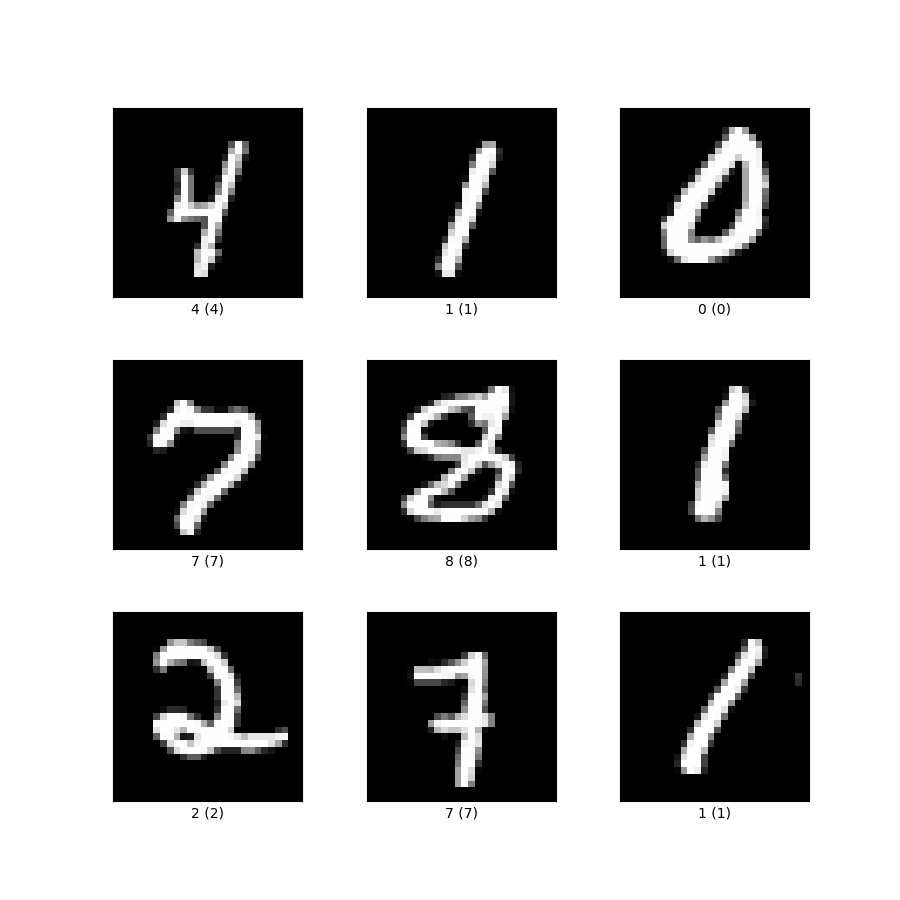

ទាយ សកម្មភាព ដោយឃើញ វីដេអូ

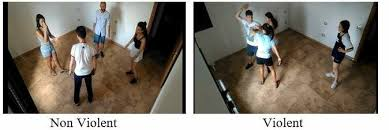

ទាយ ពាក្យបន្ទាប់ ដោយឃើញ ឃ្លា

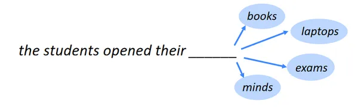

## ការធ្វើគំរូ (modeling)

ដើម្បីសម្រេចការងារ គេស្វែងរក $f(\cdot, {\mathbf{W}})$ និង ${\mathbf{W}}$ ដែល $f({\boldsymbol{x}}, {\mathbf{W}})={\boldsymbol{y}}$ ចំពោះគ្រប់តម្លៃ ${\boldsymbol{x}}$។

ជាទូទៅ៖

- ${\boldsymbol{x}}$ ហៅថា **ធាតុចូល** (Input)
- ${\boldsymbol{y}}$ ហៅថា **ធាតុចេញ** (Output)

ក្នុងករណីជាច្រើន គេក៏ហៅ ${\boldsymbol{y}}$ ថា៖

- ស្លាកសំគាល់ (label)
- សេចក្តីពិត (ground-truth)
- គោលដៅ (target)

## ការធ្វើគំរូ (modeling)

អ្នកស្រាវជ្រាវ និងអភិវឌ្ឍអេអាយ មានលទ្ធភាពតាក់តែង (design) $f$ ហើយធ្វើបរមាកម្ម (optimization) ដើម្បីស្វែងរក ${\mathbf{W}}$ ដែល

- $f$ ហៅថា **ទម្រង់ម៉ូដែល** (model architecture)
- ${\mathbf{W}}$ ហៅថា **មេគុណ** (weights) ឬ **ប៉ារ៉ាម៉ែត្រ** (parameter)

## ការធ្វើគំរូ (modeling)

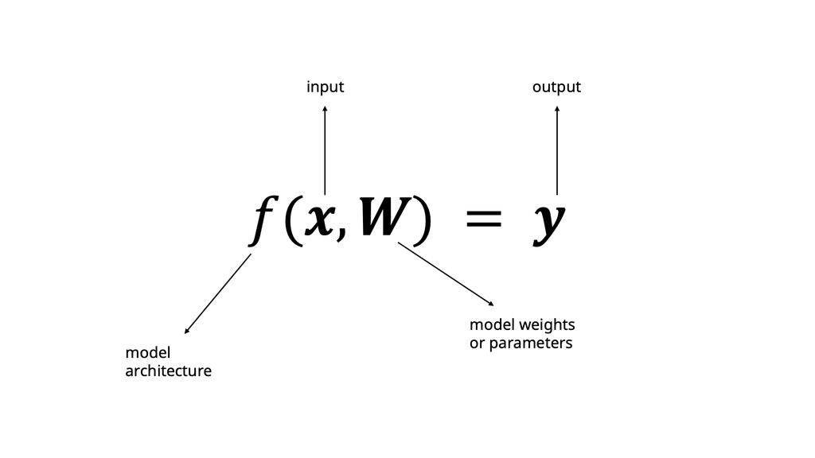

ការប្រើប្រាស់ពាក្យ **ម៉ូដែល** អាចសំដៅលើ $f$ មួយមុខគត់ ឬ ${\mathbf{W}}$ មួយមុខគត់ ឬ ទាំងពីរមុខ

# ពាក្យនិងឃ្លាទាក់ទងនឹងម៉ូដែល

## We trained a model.

- ជាភាសាខ្មែរថា ‘យើងបានបង្ហាត់ម៉ូដែលមួយ’
- ឃ្លានេះមានន័យថា៖ យើងបានរកឃើញតម្លៃមេគុណ ${\mathbf{W}}$ ដែលធ្វើអោយម៉ូដែលយើងមានសមត្ថភាពល្អ (អាចថាការទាយមានតម្លៃប្រហាក់ប្រហែលខ្លាំងទៅនឹងសេចក្តីពិត ${\boldsymbol{y}}$ ) ដោយផ្អែកលើទិន្នន័យយើងមាន $\{{\boldsymbol{x}}, {\boldsymbol{y}}\}$ (ជាទិន្នន័យបង្ហាត់ training data)

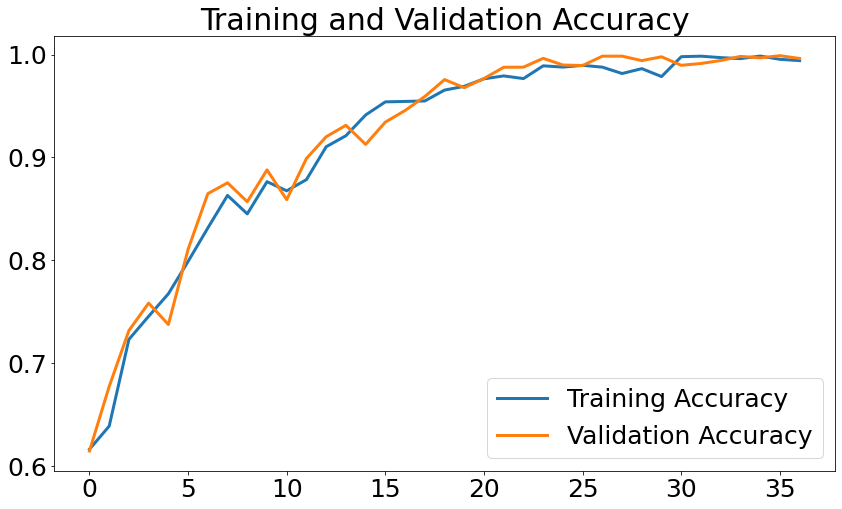

## We open-sourced a model.

- ជាភាសាខ្មែរថា ‘យើងបើកប្រភពម៉ូដែលមួយ’
- មានន័យថា៖ យ៉ាងហោចណាស់ (at the very least) $f$ និង ${\mathbf{W}}$ ត្រូវបានបញ្ចេញជាសាធារណៈ (ឧទាហរណ៍ តាមរយៈ Github, HuggingFace, ។ល។)។

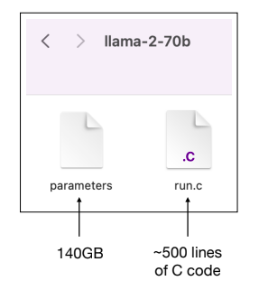

## We open-sourced a model.

- ប៉ុន្តែការនិយាយបែបនៅតែមិនទាន់ជាក់លាក់៖
  - មានរបាយការណ៍បច្ចេកទេសទេ (Technical report)?
  - ទិន្នន័យបង្ហាត់ត្រូវបានបញ្ចេញជាសាធារណៈទេ?
  - កូដសម្រាប់បង្ហាត់ម៉ូដែលត្រូវបានបញ្ចេញជាសាធារណៈទេ?
  - មានដាក់កម្មសិទ្ធិបញ្ញាអ្វីដែរលើម៉ូដែល? ព្រោះកម្មសិទ្ធិបញ្ញាខ្លះអនុញ្ញាតអោយប្រើប្រាស់សម្រាប់ការស្រាវជ្រាវប៉ុណ្ណោះ

[figure not shown]

## We launched a new model.

- ជាភាសាខ្មែរថា ‘យើងបញ្ចេញម៉ូដែលថ្មីមួយ’
- ឃ្លានេះមានភាពមិនច្បាស់លាស់ច្រើន ព្រោះវាអាចមានន័យថា $f$ ត្រូវបានបញ្ចេញ ឬ ${\mathbf{W}}$ ត្រូវបានបញ្ចេញ ឬ ទាំងពីរត្រូវបានបញ្ចេញ។

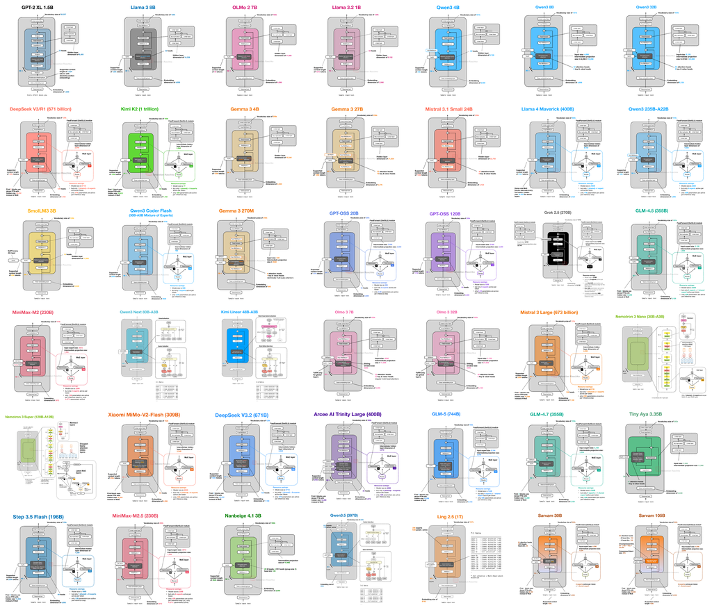

Source from https://sebastianraschka.com/llm-architecture-gallery/

## I downloaded a model.

- ជាភាសាខ្មែរថា ‘ខ្ញុំបានទាញយកម៉ូដែលមួយ’
- និយាយបែបនេះ មានន័យថាអ្នកបានទាញយក $f$ និង ${\mathbf{W}}$។ ម៉ូដែលមួយអាចសិ្ថតក្រោមទម្រង់ជា ឯកសារតែមួយ (a single file) ដូចជា llama-file ឬជា ឯកសារច្រើន (សម្រាប់ HuggingFace អ្នកទាញយក model.safetensor សម្រាប់មេគុណ, config.json, vocab.txt, tokenizer.json, etc. ហើយ ទម្រង់របស់ម៉ូដែល ត្រូវបានកំណត់ក្នុង SDK របស់ HuggingFace ដូចជា transformers library)

# ឃ្លាទូទៅដែលអាចបង្កការច្រឡំ

## The model is too large.

- ជាភាសាខ្មែរថា ‘ម៉ូដែលនេះធំពេក’
- អាចមានន័យថា៖
  - ចំនួនប៉ារ៉ាម៉ែត្រច្រើនពេក ឬកម្រិតជាក់លាក់ (floating point numbers) ខ្ពស់ពេក
  - កម្រិតផ្ទុក (storage on disk) របស់ម៉ូដែលធំពេក
  - ម៉ូដែលប្រើប្រាស់អង្គចងចាំ (RAM) ធំពេកពេលដំណើរការ

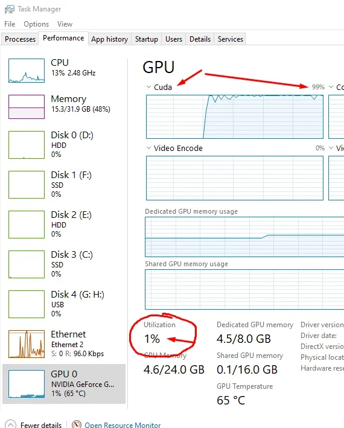

## The model is performing well.

- ជាភាសាខ្មែរថា ‘ម៉ូដែលមានសមត្ថភាពល្អ’
- អាចមានន័យថា៖
  - ការបង្ហាត់ទទួលបានជោគជ័យ៖ កំហាតពេលបង្ហាត់ (training loss) ថយចុះតាមសម្រួល
  - ការទាយរបស់ម៉ូដែលមានសុក្រិតភាពល្អចំពោះទិន្នន័យតេស្ត៍ (testing data)
  - ល្បឿនដំណើរការ (inference speed) លឿន

## Let’s fine-tune the model.

- ជាភាសាខ្មែរថា ‘តោះផ្សាំម៉ូដែលនេះ’
- អាចមានន័យថា៖
  - តោះបង្វែរមេគុណថែមទៀត ដោយប្រើប្រាស់ដុំទិន្នន័យថ្មី
  - តោះកែកុនអ៉ីពែរប៉ារ៉ាម៉ែត្រ (ដូចជាកែកម្រិតរៀន (learning rate) ឬទំហំបាច់ (batch size) តែរក្សាដុំទិន្នន័យដដែល)
  - តោះច្នៃទម្រង់ម៉ូដែលបន្តិចទៀត (ដូចជាបន្ថែមស្រទាប់ថ្មី១ជាដើម)

[figure not shown]

## We deployed a model.

- ជាភាសាខ្មែរថា ‘យើងបានដាក់ប្រើការម៉ូដែលមួយ’
- អាចមានន័យថា៖
  - យើងដាក់ម៉ូដែលលើ server ដើម្បីប្រើប្រាស់តាមរយៈ API
  - យើងធ្វើសមាហរណកម្មម៉ូដែលចូលក្នុងកម្មវិធីទូរស័ព្ទ ឬឧបករណ៍ចុង (edge device)
  - យើងសម្រិតសម្រាំង (optimize) ម៉ូដែលសម្រាប់ការប្រើប្រាស់ផ្លូវការ

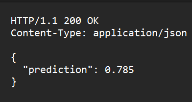

## The model is overfitting.

- ជាភាសាខ្មែរថា ‘ម៉ូដែលហ្នឹងកំពុងតែបន្ស៊ីជ្រុល’
- អាចមានន័យថា៖
  - ម៉ូដែលសូត្រទិន្នន័យបង្ហាត់ជាជាងយល់ទិដ្ឋភាពទូទៅ
  - សុក្រិតភាពពេលផ្ទៀងផ្ទាត់ (validation accuracy) តូចច្រើនដងធៀបនឹងសុក្រិតភាពពេលបង្ហាត់ (training accuracy)
  - ម៉ូដែលមានប៉ារ៉ាម៉ែត្រចំនួនច្រើនជ្រុលធៀបនឹងទំហំដុំទិន្នន័យ

[figure not shown]

## Let’s evaluate the model.

- ជាភាសាខ្មែរថា ‘តោះវាយតម្លៃម៉ូដែលហ្នឹង’
- អាចមានន័យថា៖
  - វាស់ សុក្រឹតភាព (accuracy), ភាពច្បាស់លាស់ (precision), ការរលឹក (recall) ។ល។ លើទិន្នន័យតេស្ត៍
  - តេស្ត៍ល្បឿនដំណើរការ (inference speed) របស់ម៉ូដែល
  - ឆែកភាពធន់ (robustness) របស់ម៉ូដែលចំពោះធាតុចូលបដិបក្ខ (adversarial inputs)

## The model is the state-of-the-art (SOTA).

- ជាភាសាខ្មែរថា ‘ម៉ូដែលហ្នឹងឈានមុខគេ’
- អាចមានន័យថា៖
  - ម៉ូដែលនេះទទួលបានសុក្រឹតភាពខ្ពស់ជាងគេសម្រាប់ទិន្នន័យស្តង់ដាមួយ (a benchmark)
  - ម៉ូដែលនេះប្រើប្រាស់ទម្រង់ថ្មីបំផុត (the latest architecture)

[figure not shown]

## Let’s load the model.

- ជាភាសាខ្មែរថា ‘តោះសាកម៉ូដែលហ្នឹង’
- អាចមានន័យថា៖
  - បញ្ចូលទម្រង់ម៉ូដែល និងតម្លៃមេគុណចូលក្នុងអង្គចងចាំ
  - បញ្ចូលតម្លៃមេគុណបង្ហាត់ហើយ (pre-trained weights) ពីឯកសារណាមួយ

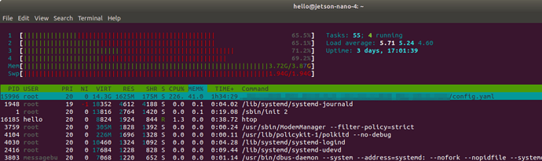

# អំពីម៉ូដែលភាសា

## ម៉ូដែលភាសាទាយពាក្យបន្ទាប់ដោយឃើញឃ្លា

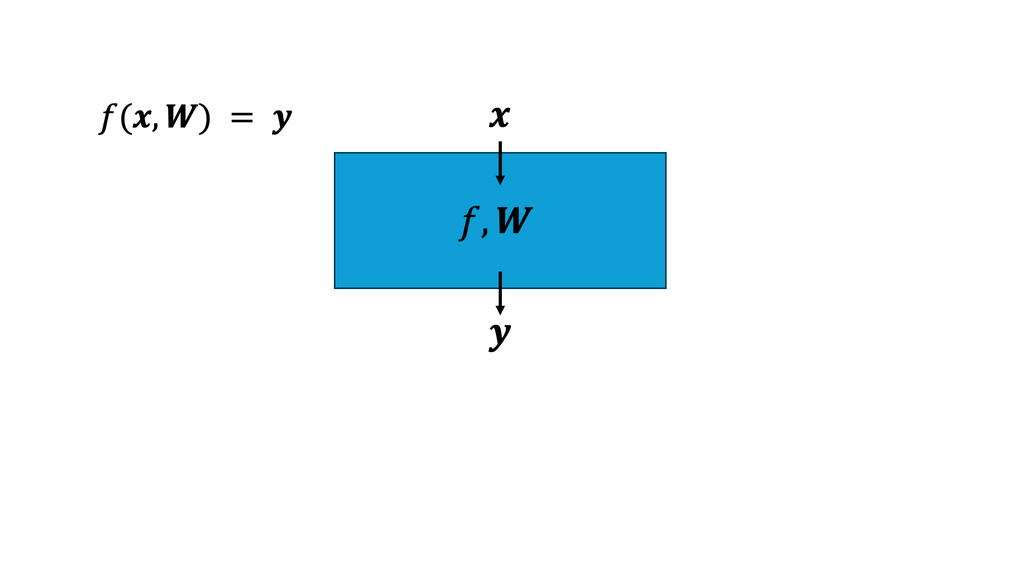

## ម៉ូដែលភាសាទាយពាក្យបន្ទាប់ដោយឃើញឃ្លា

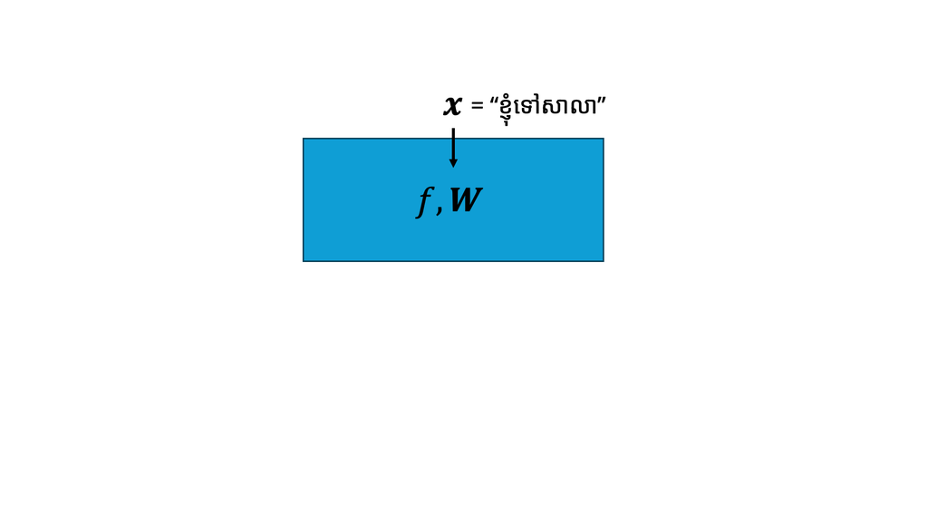

## ម៉ូដែលភាសាទាយពាក្យបន្ទាប់ដោយឃើញឃ្លា

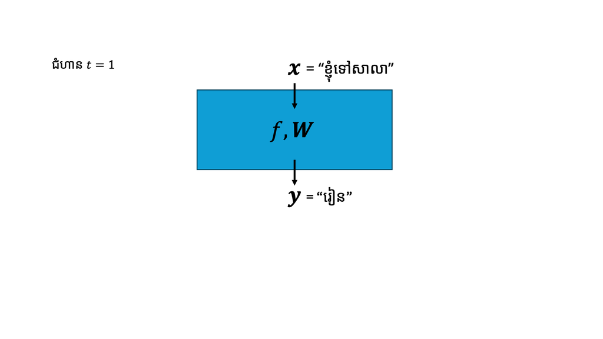

## ម៉ូដែលភាសាទាយពាក្យបន្ទាប់ដោយឃើញឃ្លា

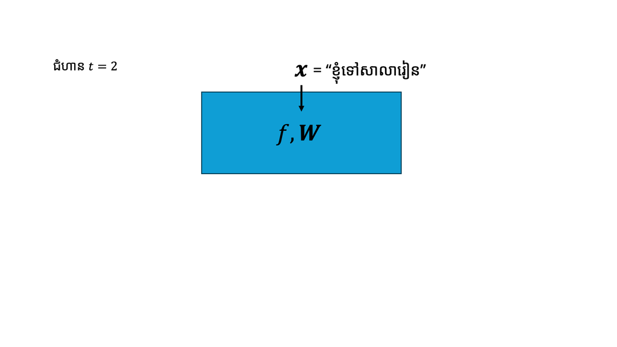

## ម៉ូដែលភាសាទាយពាក្យបន្ទាប់ដោយឃើញឃ្លា

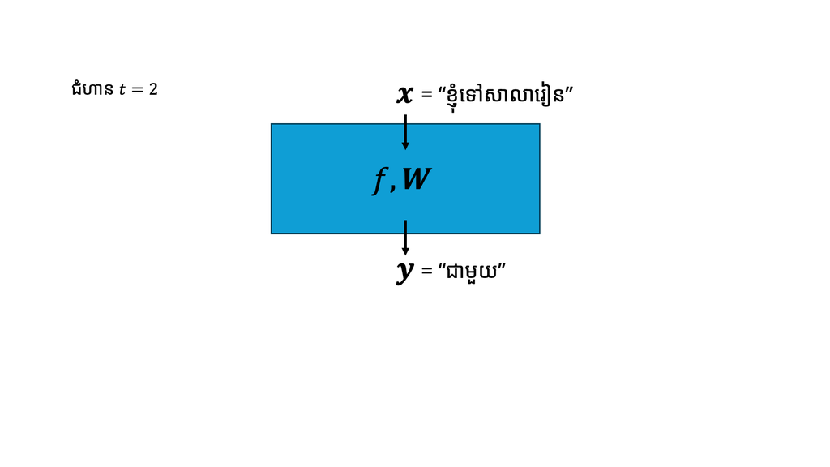

## ម៉ូដែលភាសាទាយពាក្យបន្ទាប់ដោយឃើញឃ្លា

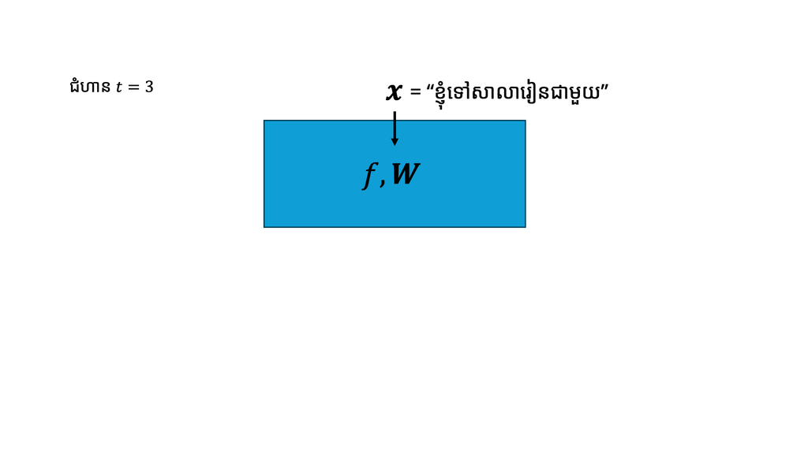

## ម៉ូដែលភាសាទាយពាក្យបន្ទាប់ដោយឃើញឃ្លា

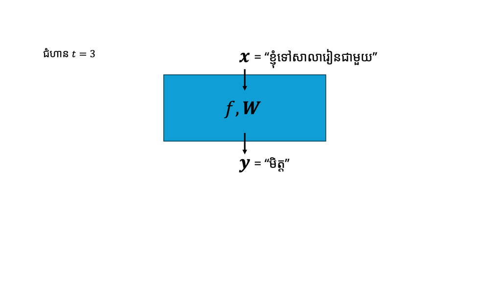

## ម៉ូដែលភាសាទាយពាក្យបន្ទាប់ដោយឃើញឃ្លា

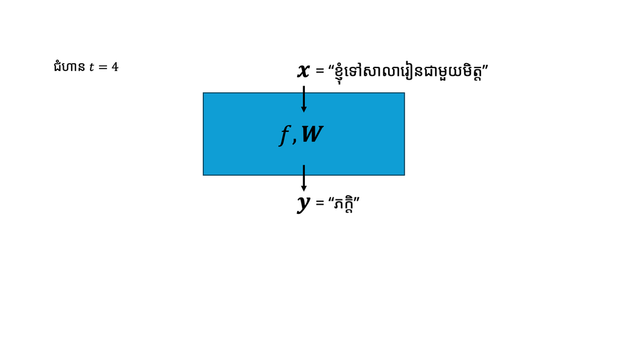

## ម៉ូដែលភាសាទាយពាក្យបន្ទាប់ដោយឃើញឃ្លា

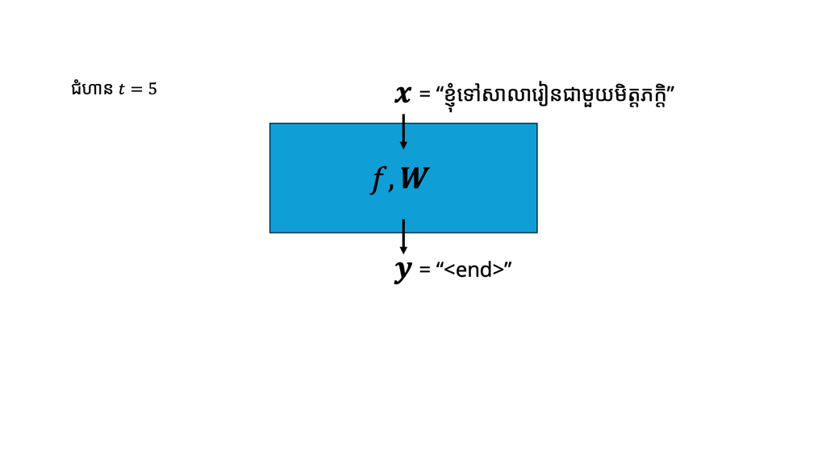

## ម៉ូដែលជាបណ្តុំនៃស្រទាប់ត្រង់ស្វូមម័រក្រោមទម្រង់ជាឌីកូដដ័រ

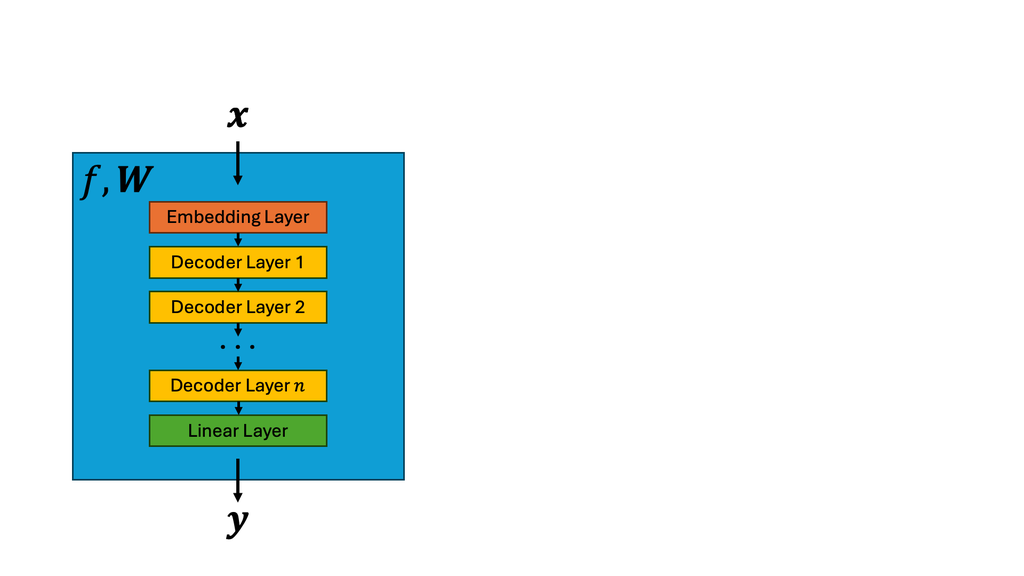

## ឃ្លាចូលត្រូវបានបំបែកជាវ៉ិចទ័រលេខមុនបំប្លែងបន្តដោយឌីកូដដ័រ

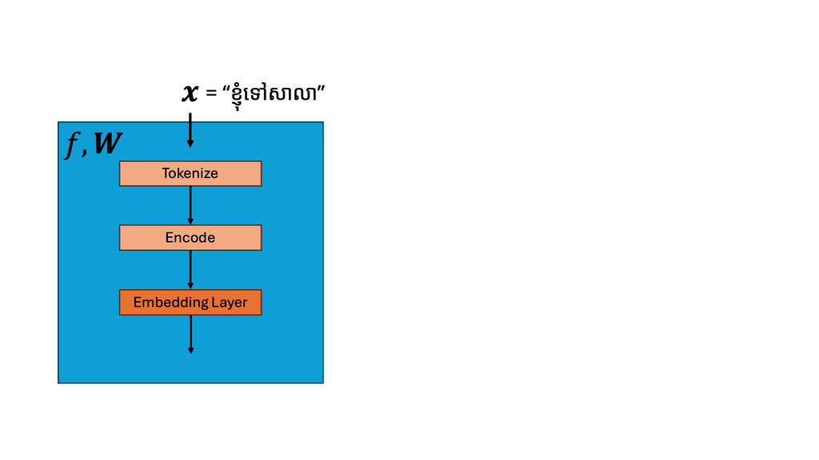

## ឃ្លាចូលត្រូវបានបំបែកជាវ៉ិចទ័រលេខមុនបំប្លែងបន្តដោយឌីកូដដ័រ

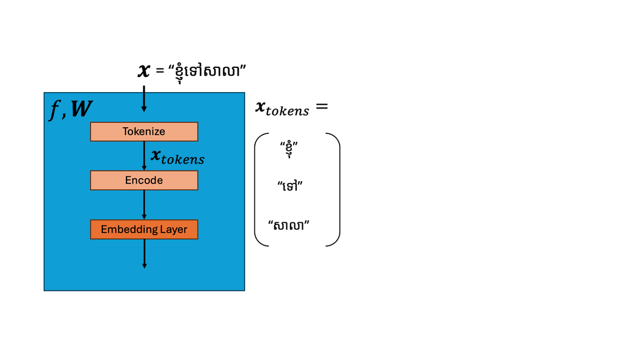

## ឃ្លាចូលត្រូវបានបំបែកជាវ៉ិចទ័រលេខមុនបំប្លែងបន្តដោយឌីកូដដ័រ

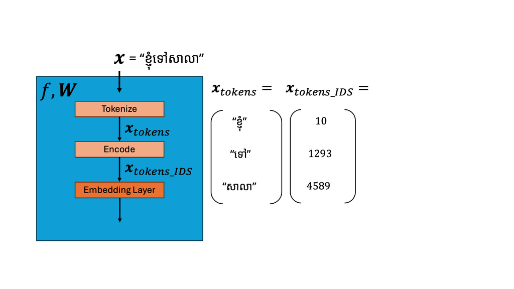

## ឃ្លាចូលត្រូវបានបំបែកជាវ៉ិចទ័រលេខមុនបំប្លែងបន្តដោយឌីកូដដ័រ

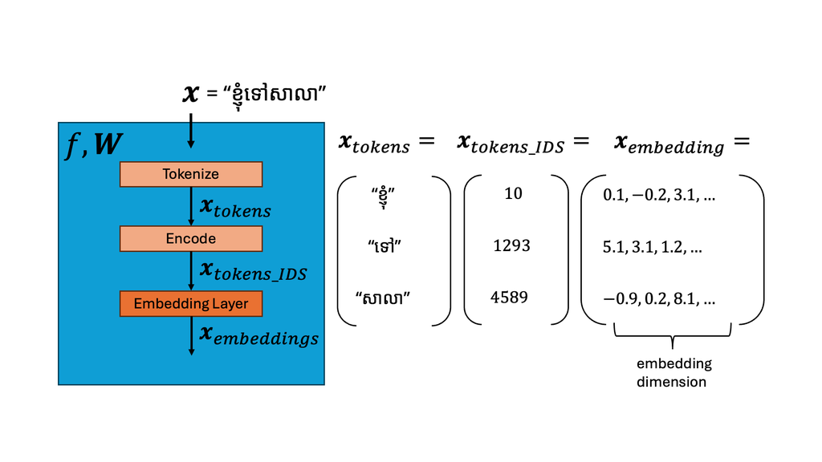

## ឃ្លាចូលត្រូវបានបំបែកជាវ៉ិចទ័រលេខមុនបំប្លែងបន្តដោយឌីកូដដ័រ

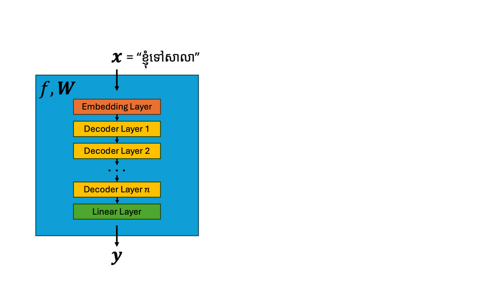

## ឃ្លាចូលត្រូវបានបំបែកជាវ៉ិចទ័រលេខមុនបំប្លែងបន្តដោយឌីកូដដ័រ

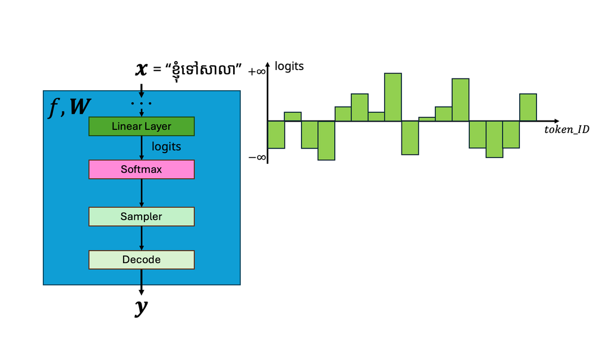

### ស្រទាប់ចុងក្រោយអោយជាឡូជីត ដែលត្រូវបំប្លែងជាប្រូបាប៊ីលីតេដែលថូខិននីមួយៗជាថូខិនបន្ទាប់

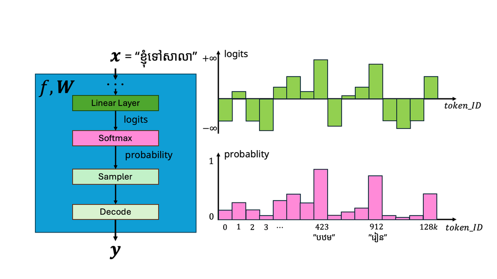

### ស្រទាប់ចុងក្រោយអោយជាឡូជីត ដែលត្រូវបំប្លែងជាប្រូបាប៊ីលីតេដែលថូខិននីមួយៗជាថូខិនបន្ទាប់

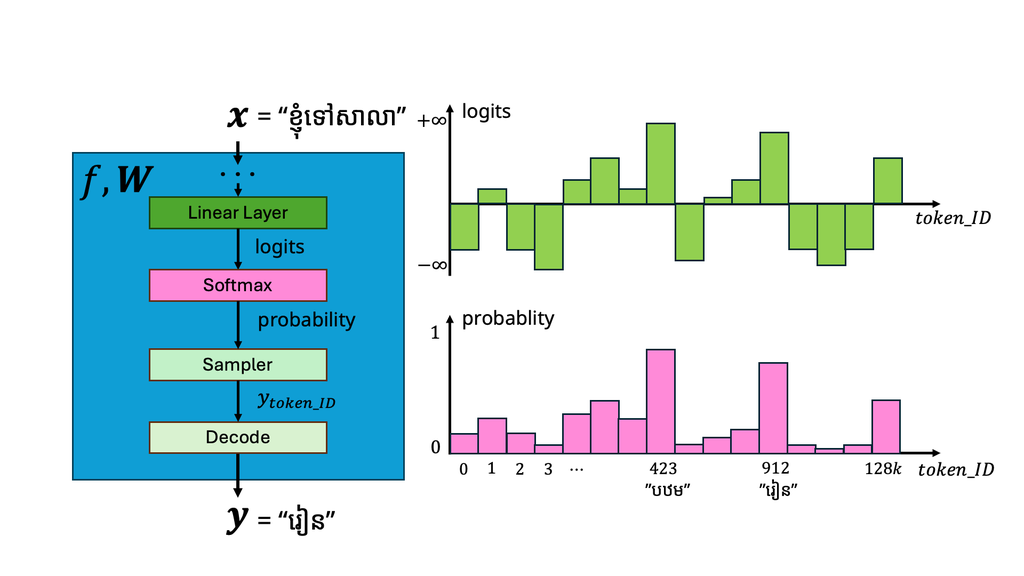

## ការបញ្ចាំងម៉ូដែលភាសា